[figure not shown]

# Case Study: Cyclistic bike-share

Google Data Analytics Professional Certificate

Felipe Altermann[^1]

17 May, 2021

# 1 How do annual members and casual riders use Cyclistic bikes differently?

- This analysis is the **Case Study 1 (Cyclistic)**[^2] from the *Google Data Analytics Certificate*, originally based on the case study `‘Sophisticated, Clear, and Polished’: Divvy and Data Visualization`, written by **Kevin Hartman**[^3] and found [here](https://artscience.blog/home/divvy-dataviz-case-study).

# 2 Scenario

- In 2016, Cyclistic, a fictional bike-share company in Chicago/US, launched a successful bike-share offering. Since then, the program has grown to a fleet of 5,824 bicycles that are geotracked and locked into a network of 692 stations across Chicago.
- Until now, Cyclistic’s marketing strategy relied on building general awareness and appealing to broad consumer segments. One approach that helped make these things possible was the flexibility of its pricing plans: single-ride passes, full-day passes, and annual memberships.
  - Customers who purchase single-ride or full-day passes are referred to as **casual users**.
  - Customers who purchase annual memberships are Cyclistic **registered members**.

## 2.1 Business Task

- The director of marketing Ms. Lily Moreno believes the company’s future success depends on **maximizing the number of annual memberships**.
- Our team wants to understand how casual riders and annual members use Cyclistic bikes differently, analyzing Cyclistic historical bike trip data to identify trends. **From these insights**, a new marketing strategy will be designed to convert casual riders into annual members.
- Three questions will guide the future marketing program:
  - **How do annual members and casual riders use Cyclistic bikes differently?**
  - Why would casual riders buy Cyclistic annual memberships?
  - How can Cyclistic use digital media to influence casual riders to become members?
- Moreno has **assigned me the first question to answer**.

## 2.2 Key stackeholders

- **Lily Moreno**, Director of Marketing and my manager. Moreno is responsible for the development of campaigns and initiatives to promote the bike-share program.
- **Cyclistic marketing analytics team**: A team of data analysts who are responsible for collecting, analyzing, and reporting data that helps guide Cyclistic marketing strategy.
- **Cyclistic executive team**: The notoriously detail-oriented executive team will decide whether to approve the recommended marketing program.

# 3 Sources

- Previous 12 months (April 2020 to March 2021) of Cyclistic’s historical trip data. The datasets have a different name because Cyclistic is a fictional company; original data can be found [here](https://divvy-tripdata.s3.amazonaws.com/index.html).
- Used **R** packages: dplyr, geosphere, ggplot2, ggpubr, ggridges, hexbin, hrbrthemes, kableExtra, knitr, lubridate, tidyverse, viridis and wesanderson.

# 4 Setting up Cyclistic environment

- Loading packages.

```r
library(dplyr)
library(geosphere)
library(ggplot2)
library(ggpubr)
library(ggridges)
library(hexbin)
library(hrbrthemes)
library(kableExtra)
library(knitr)
library(lubridate)
library(tidyverse)
library(viridis)
library(wesanderson)
```

- Collecting data

```r
# Set directory
getwd()
```

```
## [1] "/Users/felipe/divvy"
```

```r
setwd("/Users/felipe/Divvy")
# Upload Divvy dataset
trip_data_2020_04 <- read_csv("202004-divvy-tripdata.csv")
trip_data_2020_05 <- read_csv("202005-divvy-tripdata.csv")
trip_data_2020_06 <- read_csv("202006-divvy-tripdata.csv")
trip_data_2020_07 <- read_csv("202007-divvy-tripdata.csv")
trip_data_2020_08 <- read_csv("202008-divvy-tripdata.csv")
trip_data_2020_09 <- read_csv("202009-divvy-tripdata.csv")
trip_data_2020_10 <- read_csv("202010-divvy-tripdata.csv")
trip_data_2020_11 <- read_csv("202011-divvy-tripdata.csv")
trip_data_2020_12 <- read_csv("202012-divvy-tripdata.csv")
trip_data_2021_01 <- read_csv("202101-divvy-tripdata.csv")
trip_data_2021_02 <- read_csv("202102-divvy-tripdata.csv")
trip_data_2021_03 <- read_csv("202103-divvy-tripdata.csv")
```

# 5 Wrangle data and combine into a single file

## 5.1 Compare column names

### 5.1.1 One month example

```r
colnames(trip_data_2020_04)
```

```
##  [1] "ride_id"            "rideable_type"      "started_at"
##  [4] "ended_at"           "start_station_name" "start_station_id"
##  [7] "end_station_name"   "end_station_id"     "start_lat"
## [10] "start_lng"          "end_lat"            "end_lng"
## [13] "member_casual"
```

### 5.1.2 All 12 months dataframes

```r
colnames(trip_data_2020_04)
```

```
##  [1] "ride_id"            "rideable_type"      "started_at"
##  [4] "ended_at"           "start_station_name" "start_station_id"
##  [7] "end_station_name"   "end_station_id"     "start_lat"
## [10] "start_lng"          "end_lat"            "end_lng"
## [13] "member_casual"
```

```r
colnames(trip_data_2020_05)
```

```
##  [1] "ride_id"            "rideable_type"      "started_at"
##  [4] "ended_at"           "start_station_name" "start_station_id"
##  [7] "end_station_name"   "end_station_id"     "start_lat"
## [10] "start_lng"          "end_lat"            "end_lng"
## [13] "member_casual"
```

```r
colnames(trip_data_2020_06)
```

```
##  [1] "ride_id"            "rideable_type"      "started_at"
##  [4] "ended_at"           "start_station_name" "start_station_id"
##  [7] "end_station_name"   "end_station_id"     "start_lat"
## [10] "start_lng"          "end_lat"            "end_lng"
## [13] "member_casual"
```

```r
colnames(trip_data_2020_07)
```

```
##  [1] "ride_id"            "rideable_type"      "started_at"
##  [4] "ended_at"           "start_station_name" "start_station_id"
##  [7] "end_station_name"   "end_station_id"     "start_lat"
## [10] "start_lng"          "end_lat"            "end_lng"
## [13] "member_casual"
```

```r
colnames(trip_data_2020_08)
```

```
##  [1] "ride_id"            "rideable_type"      "started_at"
##  [4] "ended_at"           "start_station_name" "start_station_id"
##  [7] "end_station_name"   "end_station_id"     "start_lat"
## [10] "start_lng"          "end_lat"            "end_lng"
## [13] "member_casual"
```

```r
colnames(trip_data_2020_09)
```

```
##  [1] "ride_id"            "rideable_type"      "started_at"
##  [4] "ended_at"           "start_station_name" "start_station_id"
##  [7] "end_station_name"   "end_station_id"     "start_lat"
## [10] "start_lng"          "end_lat"            "end_lng"
## [13] "member_casual"
```

```r
colnames(trip_data_2020_10)
```

```
##  [1] "ride_id"            "rideable_type"      "started_at"
##  [4] "ended_at"           "start_station_name" "start_station_id"
##  [7] "end_station_name"   "end_station_id"     "start_lat"
## [10] "start_lng"          "end_lat"            "end_lng"
## [13] "member_casual"
```

```r
colnames(trip_data_2020_11)
```

```
##  [1] "ride_id"            "rideable_type"      "started_at"
##  [4] "ended_at"           "start_station_name" "start_station_id"
##  [7] "end_station_name"   "end_station_id"     "start_lat"
## [10] "start_lng"          "end_lat"            "end_lng"
## [13] "member_casual"
```

```r
colnames(trip_data_2020_12)
```

```
##  [1] "ride_id"            "rideable_type"      "started_at"
##  [4] "ended_at"           "start_station_name" "start_station_id"
##  [7] "end_station_name"   "end_station_id"     "start_lat"
## [10] "start_lng"          "end_lat"            "end_lng"
## [13] "member_casual"
```

```r
colnames(trip_data_2021_01)
```

```
##  [1] "ride_id"            "rideable_type"      "started_at"
##  [4] "ended_at"           "start_station_name" "start_station_id"
##  [7] "end_station_name"   "end_station_id"     "start_lat"
## [10] "start_lng"          "end_lat"            "end_lng"
## [13] "member_casual"
```

```r
colnames(trip_data_2021_02)
```

```
##  [1] "ride_id"            "rideable_type"      "started_at"
##  [4] "ended_at"           "start_station_name" "start_station_id"
##  [7] "end_station_name"   "end_station_id"     "start_lat"
## [10] "start_lng"          "end_lat"            "end_lng"
## [13] "member_casual"
```

```r
colnames(trip_data_2021_03)
```

```
##  [1] "ride_id"            "rideable_type"      "started_at"
##  [4] "ended_at"           "start_station_name" "start_station_id"
##  [7] "end_station_name"   "end_station_id"     "start_lat"
## [10] "start_lng"          "end_lat"            "end_lng"
## [13] "member_casual"
```

- Key findings:
  - Columns **names** in each collected month **are consistent**; so it will not be necessary to rename any.

## 5.2 Inspect dataframes to look for incongruencies

### 5.2.1 One month example

```r
str(trip_data_2020_04)
```

```
## spec_tbl_df[,13] [84,776 × 13] (S3: spec_tbl_df/tbl_df/tbl/data.frame)
##  $ ride_id           : chr [1:84776] "A847FADBBC638E45" "5405B80E996FF60D" "5DD24A79A4E006F4" "2A59BBDF5CDBA725" ...
##  $ rideable_type     : chr [1:84776] "docked_bike" "docked_bike" "docked_bike" "docked_bike" ...
##  $ started_at        : POSIXct[1:84776], format: "2020-04-26 17:45:14" "2020-04-17 17:08:54" ...
##  $ ended_at          : POSIXct[1:84776], format: "2020-04-26 18:12:03" "2020-04-17 17:17:03" ...
##  $ start_station_name: chr [1:84776] "Eckhart Park" "Drake Ave & Fullerton Ave" "McClurg Ct & Erie St" "California Ave & Division St" ...
##  $ start_station_id  : num [1:84776] 86 503 142 216 125 173 35 434 627 377 ...
##  $ end_station_name  : chr [1:84776] "Lincoln Ave & Diversey Pkwy" "Kosciuszko Park" "Indiana Ave & Roosevelt Rd" "Wood St & Augusta Blvd" ...
##  $ end_station_id    : num [1:84776] 152 499 255 657 323 35 635 382 359 508 ...
##  $ start_lat         : num [1:84776] 41.9 41.9 41.9 41.9 41.9 ...
##  $ start_lng         : num [1:84776] -87.7 -87.7 -87.6 -87.7 -87.6 ...
##  $ end_lat           : num [1:84776] 41.9 41.9 41.9 41.9 42 ...
##  $ end_lng           : num [1:84776] -87.7 -87.7 -87.6 -87.7 -87.7 ...
##  $ member_casual     : chr [1:84776] "member" "member" "member" "member" ...
##  - attr(*, "spec")=
##   .. cols(
##   ..   ride_id = col_character(),
##   ..   rideable_type = col_character(),
##   ..   started_at = col_datetime(format = ""),
##   ..   ended_at = col_datetime(format = ""),
##   ..   start_station_name = col_character(),
##   ..   start_station_id = col_double(),
##   ..   end_station_name = col_character(),
##   ..   end_station_id = col_double(),
##   ..   start_lat = col_double(),
##   ..   start_lng = col_double(),
##   ..   end_lat = col_double(),
##   ..   end_lng = col_double(),
##   ..   member_casual = col_character()
##   .. )
```

### 5.2.2 All 12 months dataframes

```r
str(trip_data_2020_04)
```

```
## spec_tbl_df[,13] [84,776 × 13] (S3: spec_tbl_df/tbl_df/tbl/data.frame)
##  $ ride_id           : chr [1:84776] "A847FADBBC638E45" "5405B80E996FF60D" "5DD24A79A4E006F4" "2A59BBDF5CDBA725" ...
##  $ rideable_type     : chr [1:84776] "docked_bike" "docked_bike" "docked_bike" "docked_bike" ...
##  $ started_at        : POSIXct[1:84776], format: "2020-04-26 17:45:14" "2020-04-17 17:08:54" ...
##  $ ended_at          : POSIXct[1:84776], format: "2020-04-26 18:12:03" "2020-04-17 17:17:03" ...
##  $ start_station_name: chr [1:84776] "Eckhart Park" "Drake Ave & Fullerton Ave" "McClurg Ct & Erie St" "California Ave & Division St" ...
##  $ start_station_id  : num [1:84776] 86 503 142 216 125 173 35 434 627 377 ...
##  $ end_station_name  : chr [1:84776] "Lincoln Ave & Diversey Pkwy" "Kosciuszko Park" "Indiana Ave & Roosevelt Rd" "Wood St & Augusta Blvd" ...
##  $ end_station_id    : num [1:84776] 152 499 255 657 323 35 635 382 359 508 ...
##  $ start_lat         : num [1:84776] 41.9 41.9 41.9 41.9 41.9 ...
##  $ start_lng         : num [1:84776] -87.7 -87.7 -87.6 -87.7 -87.6 ...
##  $ end_lat           : num [1:84776] 41.9 41.9 41.9 41.9 42 ...
##  $ end_lng           : num [1:84776] -87.7 -87.7 -87.6 -87.7 -87.7 ...
##  $ member_casual     : chr [1:84776] "member" "member" "member" "member" ...
##  - attr(*, "spec")=
##   .. cols(
##   ..   ride_id = col_character(),
##   ..   rideable_type = col_character(),
##   ..   started_at = col_datetime(format = ""),
##   ..   ended_at = col_datetime(format = ""),
##   ..   start_station_name = col_character(),
##   ..   start_station_id = col_double(),
##   ..   end_station_name = col_character(),
##   ..   end_station_id = col_double(),
##   ..   start_lat = col_double(),
##   ..   start_lng = col_double(),
##   ..   end_lat = col_double(),
##   ..   end_lng = col_double(),
##   ..   member_casual = col_character()
##   .. )
```

```r
str(trip_data_2020_05)
```

```
## spec_tbl_df[,13] [200,274 × 13] (S3: spec_tbl_df/tbl_df/tbl/data.frame)
##  $ ride_id           : chr [1:200274] "02668AD35674B983" "7A50CCAF1EDDB28F" "2FFCDFDB91FE9A52" "58991CF1DB75BA84" ...
##  $ rideable_type     : chr [1:200274] "docked_bike" "docked_bike" "docked_bike" "docked_bike" ...
##  $ started_at        : POSIXct[1:200274], format: "2020-05-27 10:03:52" "2020-05-25 10:47:11" ...
##  $ ended_at          : POSIXct[1:200274], format: "2020-05-27 10:16:49" "2020-05-25 11:05:40" ...
##  $ start_station_name: chr [1:200274] "Franklin St & Jackson Blvd" "Clark St & Wrightwood Ave" "Kedzie Ave & Milwaukee Ave" "Clarendon Ave & Leland Ave" ...
##  $ start_station_id  : num [1:200274] 36 340 260 251 261 206 261 180 331 219 ...
##  $ end_station_name  : chr [1:200274] "Wabash Ave & Grand Ave" "Clark St & Leland Ave" "Kedzie Ave & Milwaukee Ave" "Lake Shore Dr & Wellington Ave" ...
##  $ end_station_id    : num [1:200274] 199 326 260 157 206 22 261 180 300 305 ...
##  $ start_lat         : num [1:200274] 41.9 41.9 41.9 42 41.9 ...
##  $ start_lng         : num [1:200274] -87.6 -87.6 -87.7 -87.7 -87.7 ...
##  $ end_lat           : num [1:200274] 41.9 42 41.9 41.9 41.8 ...
##  $ end_lng           : num [1:200274] -87.6 -87.7 -87.7 -87.6 -87.6 ...
##  $ member_casual     : chr [1:200274] "member" "casual" "casual" "casual" ...
##  - attr(*, "spec")=
##   .. cols(
##   ..   ride_id = col_character(),
##   ..   rideable_type = col_character(),
##   ..   started_at = col_datetime(format = ""),
##   ..   ended_at = col_datetime(format = ""),
##   ..   start_station_name = col_character(),
##   ..   start_station_id = col_double(),
##   ..   end_station_name = col_character(),
##   ..   end_station_id = col_double(),
##   ..   start_lat = col_double(),
##   ..   start_lng = col_double(),
##   ..   end_lat = col_double(),
##   ..   end_lng = col_double(),
##   ..   member_casual = col_character()
##   .. )
```

```r
str(trip_data_2020_06)
```

```
## spec_tbl_df[,13] [343,005 × 13] (S3: spec_tbl_df/tbl_df/tbl/data.frame)
##  $ ride_id           : chr [1:343005] "8CD5DE2C2B6C4CFC" "9A191EB2C751D85D" "F37D14B0B5659BCF" "C41237B506E85FA1" ...
##  $ rideable_type     : chr [1:343005] "docked_bike" "docked_bike" "docked_bike" "docked_bike" ...
##  $ started_at        : POSIXct[1:343005], format: "2020-06-13 23:24:48" "2020-06-26 07:26:10" ...
##  $ ended_at          : POSIXct[1:343005], format: "2020-06-13 23:36:55" "2020-06-26 07:31:58" ...
##  $ start_station_name: chr [1:343005] "Wilton Ave & Belmont Ave" "Federal St & Polk St" "Daley Center Plaza" "Broadway & Cornelia Ave" ...
##  $ start_station_id  : num [1:343005] 117 41 81 303 327 327 41 115 338 84 ...
##  $ end_station_name  : chr [1:343005] "Damen Ave & Clybourn Ave" "Daley Center Plaza" "State St & Harrison St" "Broadway & Berwyn Ave" ...
##  $ end_station_id    : num [1:343005] 163 81 5 294 117 117 81 303 164 53 ...
##  $ start_lat         : num [1:343005] 41.9 41.9 41.9 41.9 41.9 ...
##  $ start_lng         : num [1:343005] -87.7 -87.6 -87.6 -87.6 -87.7 ...
##  $ end_lat           : num [1:343005] 41.9 41.9 41.9 42 41.9 ...
##  $ end_lng           : num [1:343005] -87.7 -87.6 -87.6 -87.7 -87.7 ...
##  $ member_casual     : chr [1:343005] "casual" "member" "member" "casual" ...
##  - attr(*, "spec")=
##   .. cols(
##   ..   ride_id = col_character(),
##   ..   rideable_type = col_character(),
##   ..   started_at = col_datetime(format = ""),
##   ..   ended_at = col_datetime(format = ""),
##   ..   start_station_name = col_character(),
##   ..   start_station_id = col_double(),
##   ..   end_station_name = col_character(),
##   ..   end_station_id = col_double(),
##   ..   start_lat = col_double(),
##   ..   start_lng = col_double(),
##   ..   end_lat = col_double(),
##   ..   end_lng = col_double(),
##   ..   member_casual = col_character()
##   .. )
```

```r
str(trip_data_2020_07)
```

```
## spec_tbl_df[,13] [551,480 × 13] (S3: spec_tbl_df/tbl_df/tbl/data.frame)
##  $ ride_id           : chr [1:551480] "762198876D69004D" "BEC9C9FBA0D4CF1B" "D2FD8EA432C77EC1" "54AE594E20B35881" ...
##  $ rideable_type     : chr [1:551480] "docked_bike" "docked_bike" "docked_bike" "docked_bike" ...
##  $ started_at        : POSIXct[1:551480], format: "2020-07-09 15:22:02" "2020-07-24 23:56:30" ...
##  $ ended_at          : POSIXct[1:551480], format: "2020-07-09 15:25:52" "2020-07-25 00:20:17" ...
##  $ start_station_name: chr [1:551480] "Ritchie Ct & Banks St" "Halsted St & Roscoe St" "Lake Shore Dr & Diversey Pkwy" "LaSalle St & Illinois St" ...
##  $ start_station_id  : num [1:551480] 180 299 329 181 268 635 113 211 176 31 ...
##  $ end_station_name  : chr [1:551480] "Wells St & Evergreen Ave" "Broadway & Ridge Ave" "Clark St & Wellington Ave" "Clark St & Armitage Ave" ...
##  $ end_station_id    : num [1:551480] 291 461 156 94 301 289 140 31 191 142 ...
##  $ start_lat         : num [1:551480] 41.9 41.9 41.9 41.9 41.9 ...
##  $ start_lng         : num [1:551480] -87.6 -87.6 -87.6 -87.6 -87.6 ...
##  $ end_lat           : num [1:551480] 41.9 42 41.9 41.9 41.9 ...
##  $ end_lng           : num [1:551480] -87.6 -87.7 -87.6 -87.6 -87.6 ...
##  $ member_casual     : chr [1:551480] "member" "member" "casual" "casual" ...
##  - attr(*, "spec")=
##   .. cols(
##   ..   ride_id = col_character(),
##   ..   rideable_type = col_character(),
##   ..   started_at = col_datetime(format = ""),
##   ..   ended_at = col_datetime(format = ""),
##   ..   start_station_name = col_character(),
##   ..   start_station_id = col_double(),
##   ..   end_station_name = col_character(),
##   ..   end_station_id = col_double(),
##   ..   start_lat = col_double(),
##   ..   start_lng = col_double(),
##   ..   end_lat = col_double(),
##   ..   end_lng = col_double(),
##   ..   member_casual = col_character()
##   .. )
```

```r
str(trip_data_2020_08)
```

```
## spec_tbl_df[,13] [622,361 × 13] (S3: spec_tbl_df/tbl_df/tbl/data.frame)
##  $ ride_id           : chr [1:622361] "322BD23D287743ED" "2A3AEF1AB9054D8B" "67DC1D133E8B5816" "C79FBBD412E578A7" ...
##  $ rideable_type     : chr [1:622361] "docked_bike" "electric_bike" "electric_bike" "electric_bike" ...
##  $ started_at        : POSIXct[1:622361], format: "2020-08-20 18:08:14" "2020-08-27 18:46:04" ...
##  $ ended_at          : POSIXct[1:622361], format: "2020-08-20 18:17:51" "2020-08-27 19:54:51" ...
##  $ start_station_name: chr [1:622361] "Lake Shore Dr & Diversey Pkwy" "Michigan Ave & 14th St" "Columbus Dr & Randolph St" "Daley Center Plaza" ...
##  $ start_station_id  : num [1:622361] 329 168 195 81 658 658 196 67 153 177 ...
##  $ end_station_name  : chr [1:622361] "Clark St & Lincoln Ave" "Michigan Ave & 14th St" "State St & Randolph St" "State St & Kinzie St" ...
##  $ end_station_id    : num [1:622361] 141 168 44 47 658 658 49 229 225 305 ...
##  $ start_lat         : num [1:622361] 41.9 41.9 41.9 41.9 41.9 ...
##  $ start_lng         : num [1:622361] -87.6 -87.6 -87.6 -87.6 -87.7 ...
##  $ end_lat           : num [1:622361] 41.9 41.9 41.9 41.9 41.9 ...
##  $ end_lng           : num [1:622361] -87.6 -87.6 -87.6 -87.6 -87.7 ...
##  $ member_casual     : chr [1:622361] "member" "casual" "casual" "casual" ...
##  - attr(*, "spec")=
##   .. cols(
##   ..   ride_id = col_character(),
##   ..   rideable_type = col_character(),
##   ..   started_at = col_datetime(format = ""),
##   ..   ended_at = col_datetime(format = ""),
##   ..   start_station_name = col_character(),
##   ..   start_station_id = col_double(),
##   ..   end_station_name = col_character(),
##   ..   end_station_id = col_double(),
##   ..   start_lat = col_double(),
##   ..   start_lng = col_double(),
##   ..   end_lat = col_double(),
##   ..   end_lng = col_double(),
##   ..   member_casual = col_character()
##   .. )
```

```r
str(trip_data_2020_09)
```

```
## spec_tbl_df[,13] [532,958 × 13] (S3: spec_tbl_df/tbl_df/tbl/data.frame)
##  $ ride_id           : chr [1:532958] "2B22BD5F95FB2629" "A7FB70B4AFC6CAF2" "86057FA01BAC778E" "57F6DC9A153DB98C" ...
##  $ rideable_type     : chr [1:532958] "electric_bike" "electric_bike" "electric_bike" "electric_bike" ...
##  $ started_at        : POSIXct[1:532958], format: "2020-09-17 14:27:11" "2020-09-17 15:07:31" ...
##  $ ended_at          : POSIXct[1:532958], format: "2020-09-17 14:44:24" "2020-09-17 15:07:45" ...
##  $ start_station_name: chr [1:532958] "Michigan Ave & Lake St" "W Oakdale Ave & N Broadway" "W Oakdale Ave & N Broadway" "Ashland Ave & Belle Plaine Ave" ...
##  $ start_station_id  : num [1:532958] 52 NA NA 246 24 94 291 NA NA NA ...
##  $ end_station_name  : chr [1:532958] "Green St & Randolph St" "W Oakdale Ave & N Broadway" "W Oakdale Ave & N Broadway" "Montrose Harbor" ...
##  $ end_station_id    : num [1:532958] 112 NA NA 249 24 NA 256 NA NA NA ...
##  $ start_lat         : num [1:532958] 41.9 41.9 41.9 42 41.9 ...
##  $ start_lng         : num [1:532958] -87.6 -87.6 -87.6 -87.7 -87.6 ...
##  $ end_lat           : num [1:532958] 41.9 41.9 41.9 42 41.9 ...
##  $ end_lng           : num [1:532958] -87.6 -87.6 -87.6 -87.6 -87.6 ...
##  $ member_casual     : chr [1:532958] "casual" "casual" "casual" "casual" ...
##  - attr(*, "spec")=
##   .. cols(
##   ..   ride_id = col_character(),
##   ..   rideable_type = col_character(),
##   ..   started_at = col_datetime(format = ""),
##   ..   ended_at = col_datetime(format = ""),
##   ..   start_station_name = col_character(),
##   ..   start_station_id = col_double(),
##   ..   end_station_name = col_character(),
##   ..   end_station_id = col_double(),
##   ..   start_lat = col_double(),
##   ..   start_lng = col_double(),
##   ..   end_lat = col_double(),
##   ..   end_lng = col_double(),
##   ..   member_casual = col_character()
##   .. )
```

```r
str(trip_data_2020_10)
```

```
## spec_tbl_df[,13] [388,653 × 13] (S3: spec_tbl_df/tbl_df/tbl/data.frame)
##  $ ride_id           : chr [1:388653] "ACB6B40CF5B9044C" "DF450C72FD109C01" "B6396B54A15AC0DF" "44A4AEE261B9E854" ...
##  $ rideable_type     : chr [1:388653] "electric_bike" "electric_bike" "electric_bike" "electric_bike" ...
##  $ started_at        : POSIXct[1:388653], format: "2020-10-31 19:39:43" "2020-10-31 23:50:08" ...
##  $ ended_at          : POSIXct[1:388653], format: "2020-10-31 19:57:12" "2020-11-01 00:04:16" ...
##  $ start_station_name: chr [1:388653] "Lakeview Ave & Fullerton Pkwy" "Southport Ave & Waveland Ave" "Stony Island Ave & 67th St" "Clark St & Grace St" ...
##  $ start_station_id  : num [1:388653] 313 227 102 165 190 359 313 125 NA 174 ...
##  $ end_station_name  : chr [1:388653] "Rush St & Hubbard St" "Kedzie Ave & Milwaukee Ave" "University Ave & 57th St" "Broadway & Sheridan Rd" ...
##  $ end_station_id    : num [1:388653] 125 260 423 256 185 53 125 313 199 635 ...
##  $ start_lat         : num [1:388653] 41.9 41.9 41.8 42 41.9 ...
##  $ start_lng         : num [1:388653] -87.6 -87.7 -87.6 -87.7 -87.7 ...
##  $ end_lat           : num [1:388653] 41.9 41.9 41.8 42 41.9 ...
##  $ end_lng           : num [1:388653] -87.6 -87.7 -87.6 -87.7 -87.7 ...
##  $ member_casual     : chr [1:388653] "casual" "casual" "casual" "casual" ...
##  - attr(*, "spec")=
##   .. cols(
##   ..   ride_id = col_character(),
##   ..   rideable_type = col_character(),
##   ..   started_at = col_datetime(format = ""),
##   ..   ended_at = col_datetime(format = ""),
##   ..   start_station_name = col_character(),
##   ..   start_station_id = col_double(),
##   ..   end_station_name = col_character(),
##   ..   end_station_id = col_double(),
##   ..   start_lat = col_double(),
##   ..   start_lng = col_double(),
##   ..   end_lat = col_double(),
##   ..   end_lng = col_double(),
##   ..   member_casual = col_character()
##   .. )
```

```r
str(trip_data_2020_11)
```

```
## spec_tbl_df[,13] [259,716 × 13] (S3: spec_tbl_df/tbl_df/tbl/data.frame)
##  $ ride_id           : chr [1:259716] "BD0A6FF6FFF9B921" "96A7A7A4BDE4F82D" "C61526D06582BDC5" "E533E89C32080B9E" ...
##  $ rideable_type     : chr [1:259716] "electric_bike" "electric_bike" "electric_bike" "electric_bike" ...
##  $ started_at        : POSIXct[1:259716], format: "2020-11-01 13:36:00" "2020-11-01 10:03:26" ...
##  $ ended_at          : POSIXct[1:259716], format: "2020-11-01 13:45:40" "2020-11-01 10:14:45" ...
##  $ start_station_name: chr [1:259716] "Dearborn St & Erie St" "Franklin St & Illinois St" "Lake Shore Dr & Monroe St" "Leavitt St & Chicago Ave" ...
##  $ start_station_id  : num [1:259716] 110 672 76 659 2 72 76 NA 58 394 ...
##  $ end_station_name  : chr [1:259716] "St. Clair St & Erie St" "Noble St & Milwaukee Ave" "Federal St & Polk St" "Stave St & Armitage Ave" ...
##  $ end_station_id    : num [1:259716] 211 29 41 185 2 76 72 NA 288 273 ...
##  $ start_lat         : num [1:259716] 41.9 41.9 41.9 41.9 41.9 ...
##  $ start_lng         : num [1:259716] -87.6 -87.6 -87.6 -87.7 -87.6 ...
##  $ end_lat           : num [1:259716] 41.9 41.9 41.9 41.9 41.9 ...
##  $ end_lng           : num [1:259716] -87.6 -87.7 -87.6 -87.7 -87.6 ...
##  $ member_casual     : chr [1:259716] "casual" "casual" "casual" "casual" ...
##  - attr(*, "spec")=
##   .. cols(
##   ..   ride_id = col_character(),
##   ..   rideable_type = col_character(),
##   ..   started_at = col_datetime(format = ""),
##   ..   ended_at = col_datetime(format = ""),
##   ..   start_station_name = col_character(),
##   ..   start_station_id = col_double(),
##   ..   end_station_name = col_character(),
##   ..   end_station_id = col_double(),
##   ..   start_lat = col_double(),
##   ..   start_lng = col_double(),
##   ..   end_lat = col_double(),
##   ..   end_lng = col_double(),
##   ..   member_casual = col_character()
##   .. )
```

```r
str(trip_data_2020_12)
```

```
## spec_tbl_df[,13] [131,573 × 13] (S3: spec_tbl_df/tbl_df/tbl/data.frame)
##  $ ride_id           : chr [1:131573] "70B6A9A437D4C30D" "158A465D4E74C54A" "5262016E0F1F2F9A" "BE119628E44F871E" ...
##  $ rideable_type     : chr [1:131573] "classic_bike" "electric_bike" "electric_bike" "electric_bike" ...
##  $ started_at        : POSIXct[1:131573], format: "2020-12-27 12:44:29" "2020-12-18 17:37:15" ...
##  $ ended_at          : POSIXct[1:131573], format: "2020-12-27 12:55:06" "2020-12-18 17:44:19" ...
##  $ start_station_name: chr [1:131573] "Aberdeen St & Jackson Blvd" NA NA NA ...
##  $ start_station_id  : chr [1:131573] "13157" NA NA NA ...
##  $ end_station_name  : chr [1:131573] "Desplaines St & Kinzie St" NA NA NA ...
##  $ end_station_id    : chr [1:131573] "TA1306000003" NA NA NA ...
##  $ start_lat         : num [1:131573] 41.9 41.9 41.9 41.9 41.8 ...
##  $ start_lng         : num [1:131573] -87.7 -87.7 -87.7 -87.7 -87.6 ...
##  $ end_lat           : num [1:131573] 41.9 41.9 41.9 41.9 41.8 ...
##  $ end_lng           : num [1:131573] -87.6 -87.7 -87.7 -87.7 -87.6 ...
##  $ member_casual     : chr [1:131573] "member" "member" "member" "member" ...
##  - attr(*, "spec")=
##   .. cols(
##   ..   ride_id = col_character(),
##   ..   rideable_type = col_character(),
##   ..   started_at = col_datetime(format = ""),
##   ..   ended_at = col_datetime(format = ""),
##   ..   start_station_name = col_character(),
##   ..   start_station_id = col_character(),
##   ..   end_station_name = col_character(),
##   ..   end_station_id = col_character(),
##   ..   start_lat = col_double(),
##   ..   start_lng = col_double(),
##   ..   end_lat = col_double(),
##   ..   end_lng = col_double(),
##   ..   member_casual = col_character()
##   .. )
```

```r
str(trip_data_2021_01)
```

```
## spec_tbl_df[,13] [96,834 × 13] (S3: spec_tbl_df/tbl_df/tbl/data.frame)
##  $ ride_id           : chr [1:96834] "E19E6F1B8D4C42ED" "DC88F20C2C55F27F" "EC45C94683FE3F27" "4FA453A75AE377DB" ...
##  $ rideable_type     : chr [1:96834] "electric_bike" "electric_bike" "electric_bike" "electric_bike" ...
##  $ started_at        : POSIXct[1:96834], format: "2021-01-23 16:14:19" "2021-01-27 18:43:08" ...
##  $ ended_at          : POSIXct[1:96834], format: "2021-01-23 16:24:44" "2021-01-27 18:47:12" ...
##  $ start_station_name: chr [1:96834] "California Ave & Cortez St" "California Ave & Cortez St" "California Ave & Cortez St" "California Ave & Cortez St" ...
##  $ start_station_id  : chr [1:96834] "17660" "17660" "17660" "17660" ...
##  $ end_station_name  : chr [1:96834] NA NA NA NA ...
##  $ end_station_id    : chr [1:96834] NA NA NA NA ...
##  $ start_lat         : num [1:96834] 41.9 41.9 41.9 41.9 41.9 ...
##  $ start_lng         : num [1:96834] -87.7 -87.7 -87.7 -87.7 -87.7 ...
##  $ end_lat           : num [1:96834] 41.9 41.9 41.9 41.9 41.9 ...
##  $ end_lng           : num [1:96834] -87.7 -87.7 -87.7 -87.7 -87.7 ...
##  $ member_casual     : chr [1:96834] "member" "member" "member" "member" ...
##  - attr(*, "spec")=
##   .. cols(
##   ..   ride_id = col_character(),
##   ..   rideable_type = col_character(),
##   ..   started_at = col_datetime(format = ""),
##   ..   ended_at = col_datetime(format = ""),
##   ..   start_station_name = col_character(),
##   ..   start_station_id = col_character(),
##   ..   end_station_name = col_character(),
##   ..   end_station_id = col_character(),
##   ..   start_lat = col_double(),
##   ..   start_lng = col_double(),
##   ..   end_lat = col_double(),
##   ..   end_lng = col_double(),
##   ..   member_casual = col_character()
##   .. )
```

```r
str(trip_data_2021_02)
```

```
## spec_tbl_df[,13] [49,622 × 13] (S3: spec_tbl_df/tbl_df/tbl/data.frame)
##  $ ride_id           : chr [1:49622] "89E7AA6C29227EFF" "0FEFDE2603568365" "E6159D746B2DBB91" "B32D3199F1C2E75B" ...
##  $ rideable_type     : chr [1:49622] "classic_bike" "classic_bike" "electric_bike" "classic_bike" ...
##  $ started_at        : POSIXct[1:49622], format: "2021-02-12 16:14:56" "2021-02-14 17:52:38" ...
##  $ ended_at          : POSIXct[1:49622], format: "2021-02-12 16:21:43" "2021-02-14 18:12:09" ...
##  $ start_station_name: chr [1:49622] "Glenwood Ave & Touhy Ave" "Glenwood Ave & Touhy Ave" "Clark St & Lake St" "Wood St & Chicago Ave" ...
##  $ start_station_id  : chr [1:49622] "525" "525" "KA1503000012" "637" ...
##  $ end_station_name  : chr [1:49622] "Sheridan Rd & Columbia Ave" "Bosworth Ave & Howard St" "State St & Randolph St" "Honore St & Division St" ...
##  $ end_station_id    : chr [1:49622] "660" "16806" "TA1305000029" "TA1305000034" ...
##  $ start_lat         : num [1:49622] 42 42 41.9 41.9 41.8 ...
##  $ start_lng         : num [1:49622] -87.7 -87.7 -87.6 -87.7 -87.6 ...
##  $ end_lat           : num [1:49622] 42 42 41.9 41.9 41.8 ...
##  $ end_lng           : num [1:49622] -87.7 -87.7 -87.6 -87.7 -87.6 ...
##  $ member_casual     : chr [1:49622] "member" "casual" "member" "member" ...
##  - attr(*, "spec")=
##   .. cols(
##   ..   ride_id = col_character(),
##   ..   rideable_type = col_character(),
##   ..   started_at = col_datetime(format = ""),
##   ..   ended_at = col_datetime(format = ""),
##   ..   start_station_name = col_character(),
##   ..   start_station_id = col_character(),
##   ..   end_station_name = col_character(),
##   ..   end_station_id = col_character(),
##   ..   start_lat = col_double(),
##   ..   start_lng = col_double(),
##   ..   end_lat = col_double(),
##   ..   end_lng = col_double(),
##   ..   member_casual = col_character()
##   .. )
```

```r
str(trip_data_2021_03)
```

```
## spec_tbl_df[,13] [228,496 × 13] (S3: spec_tbl_df/tbl_df/tbl/data.frame)
##  $ ride_id           : chr [1:228496] "CFA86D4455AA1030" "30D9DC61227D1AF3" "846D87A15682A284" "994D05AA75A168F2" ...
##  $ rideable_type     : chr [1:228496] "classic_bike" "classic_bike" "classic_bike" "classic_bike" ...
##  $ started_at        : POSIXct[1:228496], format: "2021-03-16 08:32:30" "2021-03-28 01:26:28" ...
##  $ ended_at          : POSIXct[1:228496], format: "2021-03-16 08:36:34" "2021-03-28 01:36:55" ...
##  $ start_station_name: chr [1:228496] "Humboldt Blvd & Armitage Ave" "Humboldt Blvd & Armitage Ave" "Shields Ave & 28th Pl" "Winthrop Ave & Lawrence Ave" ...
##  $ start_station_id  : chr [1:228496] "15651" "15651" "15443" "TA1308000021" ...
##  $ end_station_name  : chr [1:228496] "Stave St & Armitage Ave" "Central Park Ave & Bloomingdale Ave" "Halsted St & 35th St" "Broadway & Sheridan Rd" ...
##  $ end_station_id    : chr [1:228496] "13266" "18017" "TA1308000043" "13323" ...
##  $ start_lat         : num [1:228496] 41.9 41.9 41.8 42 42 ...
##  $ start_lng         : num [1:228496] -87.7 -87.7 -87.6 -87.7 -87.7 ...
##  $ end_lat           : num [1:228496] 41.9 41.9 41.8 42 42.1 ...
##  $ end_lng           : num [1:228496] -87.7 -87.7 -87.6 -87.6 -87.7 ...
##  $ member_casual     : chr [1:228496] "casual" "casual" "casual" "casual" ...
##  - attr(*, "spec")=
##   .. cols(
##   ..   ride_id = col_character(),
##   ..   rideable_type = col_character(),
##   ..   started_at = col_datetime(format = ""),
##   ..   ended_at = col_datetime(format = ""),
##   ..   start_station_name = col_character(),
##   ..   start_station_id = col_character(),
##   ..   end_station_name = col_character(),
##   ..   end_station_id = col_character(),
##   ..   start_lat = col_double(),
##   ..   start_lng = col_double(),
##   ..   end_lat = col_double(),
##   ..   end_lng = col_double(),
##   ..   member_casual = col_character()
##   .. )
```

## 5.3 Join all data frames into one big data frame

- Convert start_station_id and end_station_id to character so that they can stack correctly.

```r
trip_data_2020_04 <- mutate(trip_data_2020_04, start_station_id = as.character(start_station_id),
                            end_station_id = as.character(end_station_id))
trip_data_2020_05 <- mutate(trip_data_2020_05, start_station_id = as.character(start_station_id),
                            end_station_id = as.character(end_station_id))
trip_data_2020_06 <- mutate(trip_data_2020_06, start_station_id = as.character(start_station_id),
                            end_station_id = as.character(end_station_id))
trip_data_2020_07 <- mutate(trip_data_2020_07, start_station_id = as.character(start_station_id),
                            end_station_id = as.character(end_station_id))
trip_data_2020_08 <- mutate(trip_data_2020_08, start_station_id = as.character(start_station_id),
                            end_station_id = as.character(end_station_id))
trip_data_2020_09 <- mutate(trip_data_2020_09, start_station_id = as.character(start_station_id),
                            end_station_id = as.character(end_station_id))
trip_data_2020_10 <- mutate(trip_data_2020_10, start_station_id = as.character(start_station_id),
                            end_station_id = as.character(end_station_id))
trip_data_2020_11 <- mutate(trip_data_2020_11, start_station_id = as.character(start_station_id),
                            end_station_id = as.character(end_station_id))
```

- Stack **individual** monthly data frames **into one** big data frame:

```r
all_trips <- bind_rows(trip_data_2020_04, trip_data_2020_05, trip_data_2020_06, trip_data_2020_07, trip_data_2020_08, trip_data_2020_09, trip_data_2020_10, trip_data_2020_11, trip_data_2020_12, trip_data_2021_01, trip_data_2021_02, trip_data_2021_03)
```

# 6 Inspect the new data frame

- Since Cyclistic’s 12 months data frame is huge, glimpse() and kable() functions are a great way to quickly display and examine our data.

```r
glimpse(all_trips)
```

```
## Rows: 3,489,748
## Columns: 13
## $ ride_id            <chr> "A847FADBBC638E45", "5405B80E996FF60D", "5DD24A79A4…
## $ rideable_type      <chr> "docked_bike", "docked_bike", "docked_bike", "docke…
## $ started_at         <dttm> 2020-04-26 17:45:14, 2020-04-17 17:08:54, 2020-04-…
## $ ended_at           <dttm> 2020-04-26 18:12:03, 2020-04-17 17:17:03, 2020-04-…
## $ start_station_name <chr> "Eckhart Park", "Drake Ave & Fullerton Ave", "McClu…
## $ start_station_id   <chr> "86", "503", "142", "216", "125", "173", "35", "434…
## $ end_station_name   <chr> "Lincoln Ave & Diversey Pkwy", "Kosciuszko Park", "…
## $ end_station_id     <chr> "152", "499", "255", "657", "323", "35", "635", "38…
## $ start_lat          <dbl> 41.8964, 41.9244, 41.8945, 41.9030, 41.8902, 41.896…
## $ start_lng          <dbl> -87.6610, -87.7154, -87.6179, -87.6975, -87.6262, -…
## $ end_lat            <dbl> 41.9322, 41.9306, 41.8679, 41.8992, 41.9695, 41.892…
## $ end_lng            <dbl> -87.6586, -87.7238, -87.6230, -87.6722, -87.6547, -…
## $ member_casual      <chr> "member", "member", "member", "member", "casual", "…
```

```r
kable(head(all_trips, 10)) %>%
  kable_styling(bootstrap_options = c("striped", "hover", "condensed", "responsive"), font_size = 7, full_width = F)
```

| ride_id | rideable_type | started_at | ended_at | start_station_name | start_station_id | end_station_name | end_station_id | start_lat | start_lng | end_lat | end_lng | member_casual |
| --- | --- | --- | --- | --- | --- | --- | --- | --- | --- | --- | --- | --- |
| A847FADBBC638E45 | docked_bike | 2020-04-26 17:45:14 | 2020-04-26 18:12:03 | Eckhart Park | 86 | Lincoln Ave & Diversey Pkwy | 152 | 41.8964 | -87.6610 | 41.9322 | -87.6586 | member |
| 5405B80E996FF60D | docked_bike | 2020-04-17 17:08:54 | 2020-04-17 17:17:03 | Drake Ave & Fullerton Ave | 503 | Kosciuszko Park | 499 | 41.9244 | -87.7154 | 41.9306 | -87.7238 | member |
| 5DD24A79A4E006F4 | docked_bike | 2020-04-01 17:54:13 | 2020-04-01 18:08:36 | McClurg Ct & Erie St | 142 | Indiana Ave & Roosevelt Rd | 255 | 41.8945 | -87.6179 | 41.8679 | -87.6230 | member |
| 2A59BBDF5CDBA725 | docked_bike | 2020-04-07 12:50:19 | 2020-04-07 13:02:31 | California Ave & Division St | 216 | Wood St & Augusta Blvd | 657 | 41.9030 | -87.6975 | 41.8992 | -87.6722 | member |
| 27AD306C119C6158 | docked_bike | 2020-04-18 10:22:59 | 2020-04-18 11:15:54 | Rush St & Hubbard St | 125 | Sheridan Rd & Lawrence Ave | 323 | 41.8902 | -87.6262 | 41.9695 | -87.6547 | casual |
| 356216E875132F61 | docked_bike | 2020-04-30 17:55:47 | 2020-04-30 18:01:11 | Mies van der Rohe Way & Chicago Ave | 173 | Streeter Dr & Grand Ave | 35 | 41.8969 | -87.6217 | 41.8923 | -87.6120 | member |
| A2759CB06A81F2BC | docked_bike | 2020-04-02 14:47:19 | 2020-04-02 14:52:32 | Streeter Dr & Grand Ave | 35 | Fairbanks St & Superior St | 635 | 41.8923 | -87.6120 | 41.8957 | -87.6201 | member |
| FC8BC2E2D54F35ED | docked_bike | 2020-04-07 12:22:20 | 2020-04-07 13:38:09 | Ogden Ave & Roosevelt Rd | 434 | Western Ave & Congress Pkwy | 382 | 41.8665 | -87.6847 | 41.8747 | -87.6864 | casual |
| 9EC5648678DE06E6 | docked_bike | 2020-04-15 10:30:11 | 2020-04-15 10:35:55 | LaSalle Dr & Huron St | 627 | Larrabee St & Division St | 359 | 41.8949 | -87.6323 | 41.9035 | -87.6434 | casual |
| A8FFF89140C33017 | docked_bike | 2020-04-04 15:02:28 | 2020-04-04 15:19:47 | Kedzie Ave & Lake St | 377 | Central Park Ave & North Ave | 508 | 41.8846 | -87.7063 | 41.9097 | -87.7166 | member |

- Key findings:
  - Original data bank has **3,489,748 rows** with **59% registered members** and **41% casual users**;
  - Some columns will not be needed for further analysis, like ride_id;
  - Other columns will be used to run calculations only: start_lat, start_lng, end_lat and end_lng to find out ride distance.

# 7 Clean up and add data to prepare for analysis

## 7.1 Create new columns to provide additional opportunities to aggregate the data

- Add columns that list the date, month, day, year and weekday.

```r
all_trips$date <- as.Date(all_trips$started_at)
all_trips$month <- format(as.Date(all_trips$date), "%m")
all_trips$day <- format(as.Date(all_trips$date), "%d")
all_trips$year <- format(as.Date(all_trips$date), "%Y")
all_trips$day_of_week <- format(as.Date(all_trips$date), "%A")
```

- Add calculation for “ride_length” (in seconds) and “ride_distance” (in km) in new columns.

```r
all_trips$ride_length <- difftime(all_trips$ended_at,all_trips$started_at)
all_trips$ride_distance <- distGeo(matrix(c(all_trips$start_lng, all_trips$start_lat), ncol = 2),
                                      matrix(c(all_trips$end_lng, all_trips$end_lat), ncol = 2))/1000
all_trips$ride_distance <- round(all_trips$ride_distance, digits = 2)
```

- Inspect the new structure of the columns.

```r
str(all_trips)
```

```
## spec_tbl_df[,20] [3,489,748 × 20] (S3: spec_tbl_df/tbl_df/tbl/data.frame)
##  $ ride_id           : chr [1:3489748] "A847FADBBC638E45" "5405B80E996FF60D" "5DD24A79A4E006F4" "2A59BBDF5CDBA725" ...
##  $ rideable_type     : chr [1:3489748] "docked_bike" "docked_bike" "docked_bike" "docked_bike" ...
##  $ started_at        : POSIXct[1:3489748], format: "2020-04-26 17:45:14" "2020-04-17 17:08:54" ...
##  $ ended_at          : POSIXct[1:3489748], format: "2020-04-26 18:12:03" "2020-04-17 17:17:03" ...
##  $ start_station_name: chr [1:3489748] "Eckhart Park" "Drake Ave & Fullerton Ave" "McClurg Ct & Erie St" "California Ave & Division St" ...
##  $ start_station_id  : chr [1:3489748] "86" "503" "142" "216" ...
##  $ end_station_name  : chr [1:3489748] "Lincoln Ave & Diversey Pkwy" "Kosciuszko Park" "Indiana Ave & Roosevelt Rd" "Wood St & Augusta Blvd" ...
##  $ end_station_id    : chr [1:3489748] "152" "499" "255" "657" ...
##  $ start_lat         : num [1:3489748] 41.9 41.9 41.9 41.9 41.9 ...
##  $ start_lng         : num [1:3489748] -87.7 -87.7 -87.6 -87.7 -87.6 ...
##  $ end_lat           : num [1:3489748] 41.9 41.9 41.9 41.9 42 ...
##  $ end_lng           : num [1:3489748] -87.7 -87.7 -87.6 -87.7 -87.7 ...
##  $ member_casual     : chr [1:3489748] "member" "member" "member" "member" ...
##  $ date              : Date[1:3489748], format: "2020-04-26" "2020-04-17" ...
##  $ month             : chr [1:3489748] "04" "04" "04" "04" ...
##  $ day               : chr [1:3489748] "26" "17" "01" "07" ...
##  $ year              : chr [1:3489748] "2020" "2020" "2020" "2020" ...
##  $ day_of_week       : chr [1:3489748] "Sunday" "Friday" "Wednesday" "Tuesday" ...
##  $ ride_length       : 'difftime' num [1:3489748] 1609 489 863 732 ...
##   ..- attr(*, "units")= chr "secs"
##  $ ride_distance     : num [1:3489748] 3.98 0.98 2.98 2.14 9.12 0.95 0.77 0.92 1.33 2.92 ...
##  - attr(*, "spec")=
##   .. cols(
##   ..   ride_id = col_character(),
##   ..   rideable_type = col_character(),
##   ..   started_at = col_datetime(format = ""),
##   ..   ended_at = col_datetime(format = ""),
##   ..   start_station_name = col_character(),
##   ..   start_station_id = col_double(),
##   ..   end_station_name = col_character(),
##   ..   end_station_id = col_double(),
##   ..   start_lat = col_double(),
##   ..   start_lng = col_double(),
##   ..   end_lat = col_double(),
##   ..   end_lng = col_double(),
##   ..   member_casual = col_character()
##   .. )
```

## 7.2 Create new data frame since data is being removed

- Convert “ride_length” and “ride_distance” to numeric to run calculations on the data.

```r
all_trips$ride_length <- as.numeric(as.character(all_trips$ride_length))
all_trips$ride_distance <- as.numeric(as.character(all_trips$ride_distance))
```

- Check number of rows with NAs.

```r
format(sum(!complete.cases(all_trips[-1])), big.mark = ",")
```

```
## [1] "195,057"
```

- **Remove entries:**
  1. When bikes were taken out of docks and checked for quality by Divvy or `ride_length` is negative;
  2. Drop all NA’s;
  3. Remove unnecessary columns for further data analysis.
- Create **new data frame version (v2)**.

```r
all_trips_v2 <- all_trips[!(all_trips$start_station_name == "HQ QR" | all_trips$ride_length<0),]
all_trips_v2 <- drop_na(all_trips_v2)
all_trips_v2 <- all_trips_v2 %>%
  select(-c(ride_id, started_at, start_station_name, start_station_id, ended_at, end_station_name, end_station_id, start_lat, start_lng, end_lat, end_lng))
```

- Rename “member_casual” column to “user_type”.

```r
all_trips_v2 <- rename(all_trips_v2, user_type = member_casual)
```

- Fix order of “days_of_week”.

```r
all_trips_v2$day_of_week <- ordered(all_trips_v2$day_of_week, levels=c("Monday", "Tuesday", "Wednesday", "Thursday", "Friday", "Saturday", "Sunday"))
```

## 7.3 Check for bad data

```r
count(all_trips, ride_length == 0 & start_station_id == end_station_id)
```

```
## # A tibble: 3 x 2
##   `ride_length == 0 & start_station_id == end_station_id`       n
##   <lgl>                                                     <int>
## 1 FALSE                                                   3489538
## 2 TRUE                                                        113
## 3 NA                                                           97
```

```r
count(all_trips_v2, ride_length == 0)
```

```
## # A tibble: 2 x 2
##   `ride_length == 0`       n
##   <lgl>                <int>
## 1 FALSE              3283948
## 2 TRUE                   289
```

```r
bad_data <- as.data.frame(table(all_trips_v2$ride_length))
bad_data$Var1 <- as.integer(bad_data$Var1)
bad_data$Freq <- as.double(bad_data$Freq)
```

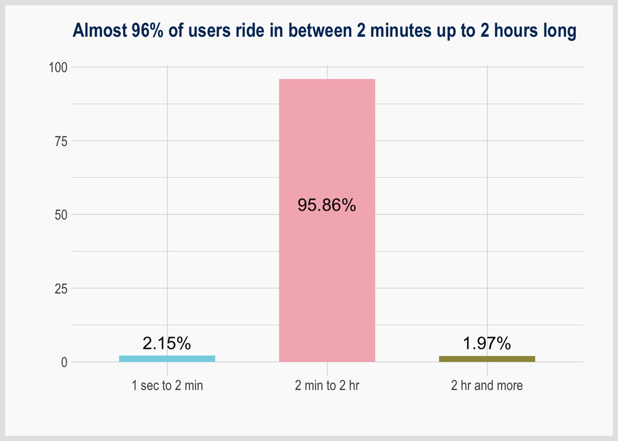

```r
bad_data_plot <- data.frame(
  time = c("1 sec to 2 min", "2 min to 2 hr", "2 hr and more"),
  perc = as.double(c(
    with(bad_data, round(100 * sum(Freq[Var1 < 120]) / sum(Freq), 2)),
    with(bad_data, round(100 * sum(Freq[Var1 > 120 & Var1 < 7200]) / sum(Freq), 2)),
    with(bad_data, round(100 * sum(Freq[Var1 > 7200]) / sum(Freq), 2))))
)
bad_data_plot$time <- factor(bad_data_plot$time, levels = c("1 sec to 2 min", "2 min to 2 hr", "2 hr and more"))
ggplot(bad_data_plot, aes(time, perc, fill = time)) +
  geom_bar(width=.6, stat="identity") +
  geom_text(aes(label = paste0(perc,"%")), vjust = -0.8, size = 5, position = position_stack(vjust = 0.5)) +
  scale_fill_manual(values = wes_palette("Moonrise3")) +
  guides(fill=FALSE) +
  xlab(" ") + ylab(" ") +
  ggtitle("Almost 96% of users ride in between 2 minutes up to 2 hours long") +
  theme_ipsum() +
  theme(
    plot.title = element_text(face = "bold", color = "#003366", size = 16, hjust = 0.2, vjust = 4),
    plot.margin = margin(1, 1, 1, 1, "cm"),
    plot.background = element_rect(fill = "grey98", colour = "grey90", size = 4),
    axis.text = element_text(size = rel(1.1))
  )
```

- Key findings:
  - 2.15% of all rides lasted less than 2 minutes long; 1.97% were longer than 2 hours;
  - Yet with 95.86% the vast majority of users rented a bike in between the above time frame.

## 7.4 Check for outliers

### 7.4.1 Outlier 1

```r
aggregate(bad_data["Freq"], list(cut(bad_data$Var1, (0:1)*120, right = TRUE)), sum)
```

```
##   Group.1  Freq
## 1 (0,120] 71355
```

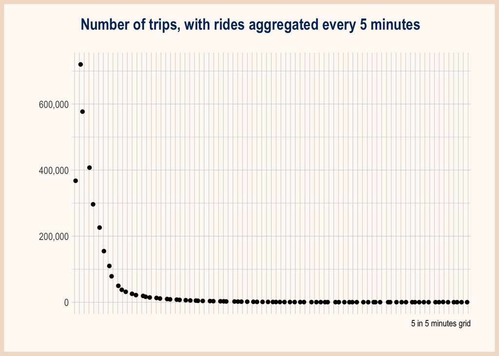

```r
outlier_1 <- aggregate(bad_data["Freq"], list(cut(bad_data$Var1, (0:83)*300, right = TRUE)), sum)
ggplot(outlier_1, aes(Group.1, Freq, fill = Freq)) +
  geom_jitter() +
  scale_x_discrete(drop = FALSE) +
  guides(fill=FALSE) +
  xlab(" ") + ylab(" ") +
  ggtitle("Number of trips, with rides aggregated every 5 minutes") +
  theme_ipsum() +
  xlab("5 in 5 minutes grid") +
  theme(
    plot.title = element_text(face = "bold", color = "#003366", size = 16, hjust = 0.15, vjust = 4),
    plot.margin = margin(1, 1, 1, 1, "cm"),
    plot.background = element_rect(fill = "#fff9f5", colour = "#f2dfce", size = 4),
    axis.text.x = element_blank(),
    axis.text.y = element_text(size = rel(1.1))
  ) +
  scale_y_continuous(labels = scales::comma)
```

### 7.4.2 Outlier 2

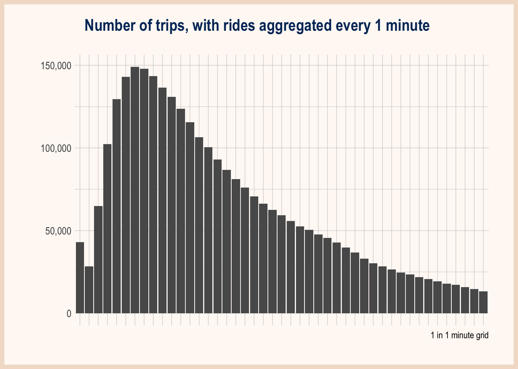

```r
outlier_2 <- aggregate(bad_data["Freq"], list(cut(bad_data$Var1, (0:45)*60, right = TRUE)), sum)
ggplot(outlier_2, aes(Group.1, Freq)) +
  geom_col(position = "dodge") +
  guides(fill=FALSE) +
  xlab(" ") + ylab(" ") +
  ggtitle("Number of trips, with rides aggregated every 1 minute") +
  theme_ipsum() +
  xlab("1 in 1 minute grid") +
  theme(
    plot.title = element_text(face = "bold", color = "#003366", size = 16, hjust = 0.15, vjust = 4),
    plot.margin = margin(1, 1, 1, 1, "cm"),
    plot.background = element_rect(fill = "#fff9f5", colour = "#f2dfce", size = 4),
    axis.text.x = element_blank(),
    axis.text.y = element_text(size = rel(1.1))
  ) +
  scale_y_continuous(labels = scales::comma)
```

- Key findings:
  - Data frame has some trips with zero second duration as well as same start and end Stations, meaning users quit renting a bike.

N.B.: To help me with a particular code in the last section, I asked my fellow **R** coders @ stack**overflow**: `How to sum one column values and group them by intervals from another column.` Great answers can be found [here](https://stackoverflow.com/questions/67370796/).

# 8 Final data frame for analysis

- Based on the findings and after discussing the subject with my manager Ms. Lily Moreno, **final decision** was to focus our further analysis on data from **users** with **trips longer than 2 minutes and shorter than 2 hours**.
- Create **new data frame (v3)** since data is being removed

```r
all_trips_v3 <- all_trips_v2 %>%
  subset(ride_length > 120 & ride_length < 7201)
```

```r
kable(head(all_trips_v3, 10)) %>%
  kable_paper("hover", "striped", font_size = 16, full_width = F)
```

| rideable_type | user_type | date | month | day | year | day_of_week | ride_length | ride_distance |
| --- | --- | --- | --- | --- | --- | --- | --- | --- |
| docked_bike | member | 2020-04-26 | 04 | 26 | 2020 | Sunday | 1609 | 3.98 |
| docked_bike | member | 2020-04-17 | 04 | 17 | 2020 | Friday | 489 | 0.98 |
| docked_bike | member | 2020-04-01 | 04 | 01 | 2020 | Wednesday | 863 | 2.98 |
| docked_bike | member | 2020-04-07 | 04 | 07 | 2020 | Tuesday | 732 | 2.14 |
| docked_bike | casual | 2020-04-18 | 04 | 18 | 2020 | Saturday | 3175 | 9.12 |
| docked_bike | member | 2020-04-30 | 04 | 30 | 2020 | Thursday | 324 | 0.95 |
| docked_bike | member | 2020-04-02 | 04 | 02 | 2020 | Thursday | 313 | 0.77 |
| docked_bike | casual | 2020-04-07 | 04 | 07 | 2020 | Tuesday | 4549 | 0.92 |
| docked_bike | casual | 2020-04-15 | 04 | 15 | 2020 | Wednesday | 344 | 1.33 |
| docked_bike | member | 2020-04-04 | 04 | 04 | 2020 | Saturday | 1039 | 2.92 |

## 8.1 User and bike types

- Cyclistic has 2 different types of clients: **40% casual users** and **60% registered members**.
- Clients could choose between 3 available types of bike:
  - **casual users** rented: 2.16% classic, **33% docked** and 5.08% electric bikes;
  - **registered members** rented: 7.67% classic, **44.2% docked** and 7.88% electric bikes.

### 8.1.1 User types plot

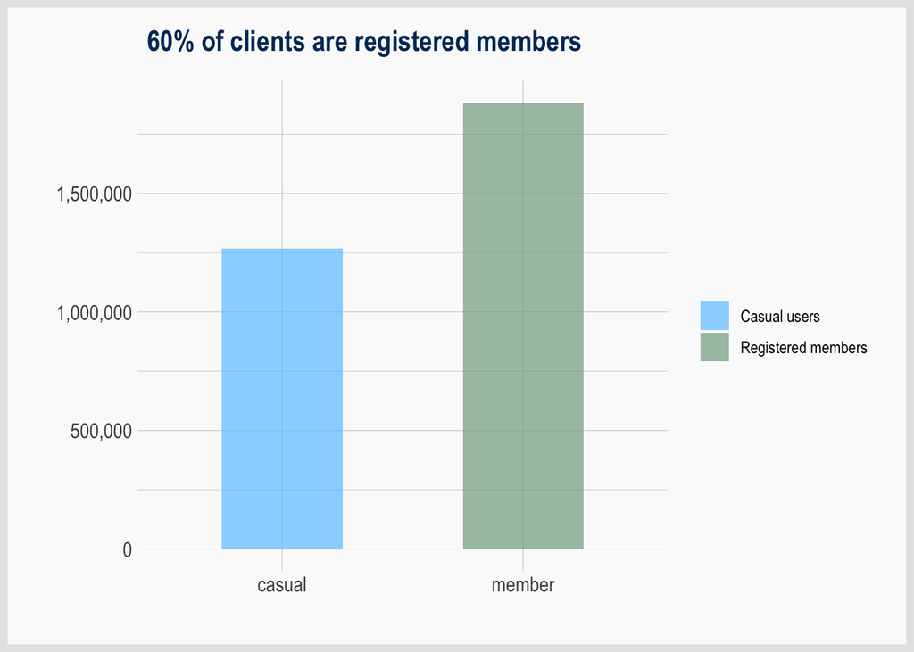

```r
all_trips_v3 %>%
  group_by(user_type) %>%
  summarise(number_of_users = n(), .groups = 'drop') %>%
  arrange(user_type) %>%
  ggplot(aes(user_type, number_of_users, fill = user_type)) +
  geom_bar(width=.5, position = "stack", stat = "identity") +
  ggtitle("60% of clients are registered members") +
  theme_ipsum() +
  xlab("") + ylab("") +
  theme(plot.title = element_text(face = "bold", color = "#003366", size = 16, hjust = 0.1, vjust = 2),
        plot.margin = margin(0.7, 0.7, 0.7, 0.7, "cm"),
        plot.background = element_rect(fill = "grey98", colour = "grey90", size = 4),
        axis.text = element_text(size = rel(0.8)),
        legend.title = element_blank()) +
  scale_fill_manual(labels = c("Casual users", "Registered members"), values = alpha(c("#69c6ff", "#81A88D"), 0.7)) +
  scale_y_continuous(labels = scales::comma)
```

### 8.1.2 Bike types plot

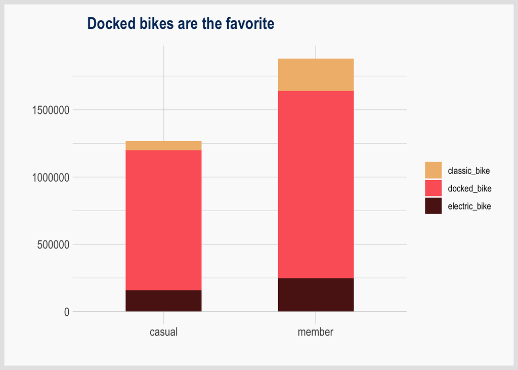

```r
all_trips_v3 %>%
  group_by(user_type, rideable_type) %>%
  summarise(number_of_users = n(), .groups = 'drop') %>%
  arrange(user_type, rideable_type) %>%
  ggplot(aes(user_type, number_of_users, fill = rideable_type)) +
  geom_bar(width=.5, position = "stack", stat = "identity") +
  ggtitle("Docked bikes are the favorite") +
  theme_ipsum() +
  xlab("") + ylab("") +
  scale_fill_manual(values = wes_palette("GrandBudapest1")) +
  theme(plot.title = element_text(face = "bold", color = "#003366", size = 16, hjust = 0.1, vjust = 2),
        plot.margin = margin(0.7, 0.7, 0.7, 0.7, "cm"),
        plot.background = element_rect(fill = "grey98", colour = "grey90", size = 4),
        axis.text = element_text(size = rel(0.8)),
        legend.title = element_blank())
```

- Key findings:
  - There was no surprise that more than 3/4 of rentals are docked bikes, since they are an upgraded version of the simplest and most affordable classic option;
  - Electric bikes usage lead to an extra cost in a per-minute basis, so it has very few rentals.
  - Casual users vs. Registered members:
    - 40% of clients are casual users and the potential riders to convert into annual members;
    - Marketing campaign should focus on **docked bikes**, as those are by far the most rented type.

## 8.2 Number of rides

- **3,147,580** rides have been performed by users.

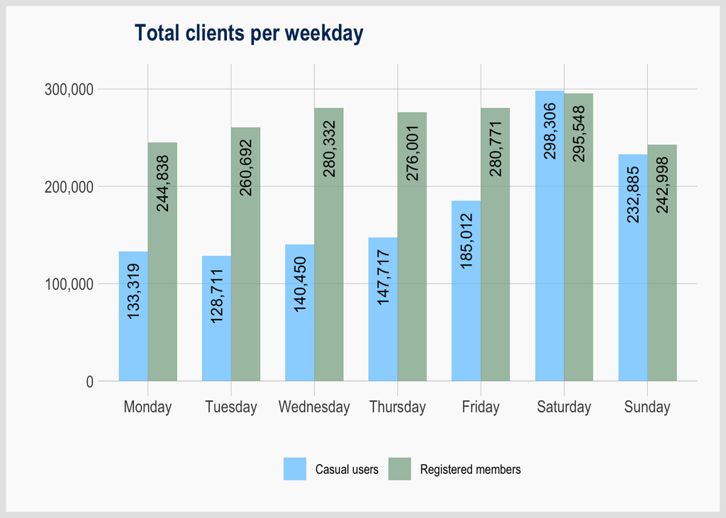

```r
all_trips_v3 %>%
  group_by(user_type, day_of_week) %>%
  summarise(number_of_rides = n(), .groups = 'drop') %>%
  arrange(user_type, day_of_week) %>%
  ggplot(aes(day_of_week, number_of_rides, fill = user_type)) +
  geom_col(width=.7, position = "dodge") +
  theme_ipsum() +
  geom_text(aes(label = format(number_of_rides, big.mark = ",")),
    angle = 90, position = position_dodge(0.7), vjust = 0.5, hjust = 1.2) +
  xlab("") + ylab("") +
  ggtitle("Total clients per weekday") +
  theme(plot.title = element_text(face = "bold", color = "#003366", size = 16, hjust = 0.1, vjust = 2),
    plot.margin = margin(0.7, 0.7, 0.7, 0.7, "cm"),
    plot.background = element_rect(fill = "grey98", colour = "grey90", size = 4),
    axis.text = element_text(size = rel(0.8)),
    legend.title = element_blank(),
    legend.position = "bottom") +
  scale_fill_manual(labels = c("Casual users", "Registered members"), values = alpha(c("#69c6ff", "#81A88D"), 0.7)) +
  scale_y_continuous(breaks = c(0, 100000, 200000, 300000), minor_breaks = seq(0, 1, 1), labels = scales::comma, limits = c(min(0), max(310000)))
```

## 8.3 Length of rides

- Focus on data from riders with rents taking from 2 minutes up to 2 hours long.

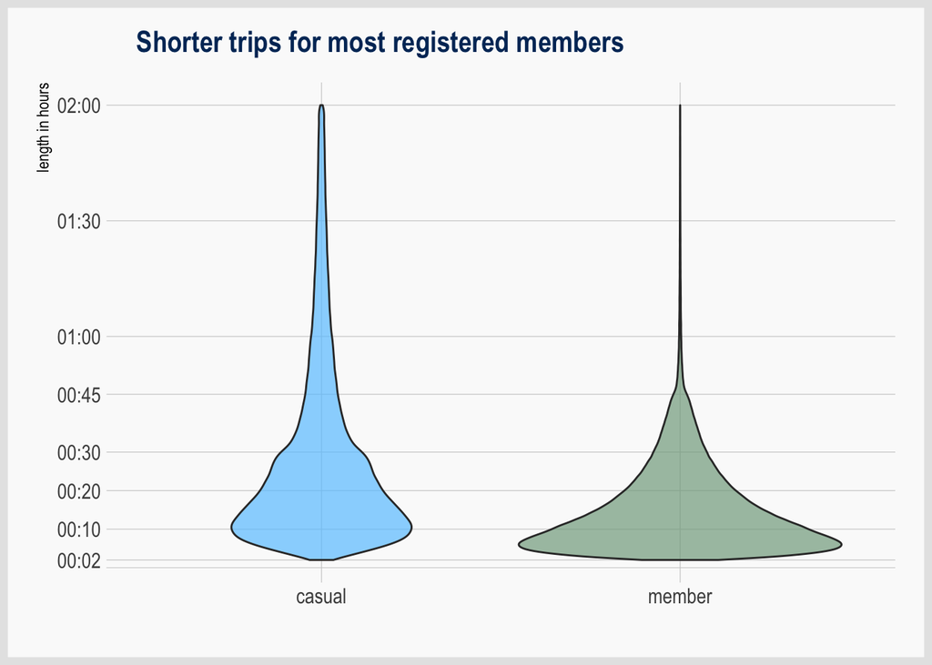

```r
all_trips_v3 %>%
  ggplot(aes(user_type, ride_length, fill = user_type)) +
  geom_violin() +
  theme_ipsum() +
  xlab("") + ylab("") +
  ggtitle("Shorter trips for most registered members") +
  theme(plot.title = element_text(face = "bold", color = "#003366", size = 16, hjust = 0.1, vjust = 2),
        plot.margin = margin(0.7, 0.7, 0.7, 0.7, "cm"),
        plot.background = element_rect(fill = "grey98", colour = "grey90", size = 4),
        axis.text = element_text(size = rel(0.8)),
        legend.position="none") +
  scale_fill_manual(values = alpha(c("#69c6ff", "#81A88D"), 0.7)) +
  scale_y_time(name = "length in hours", labels = function(l) strftime(l, '%H:%M'), breaks = c(120, 600, 1200, 1800, 2700, 3600, 5400, 7200), minor_breaks = seq(0, 1, 1))
```

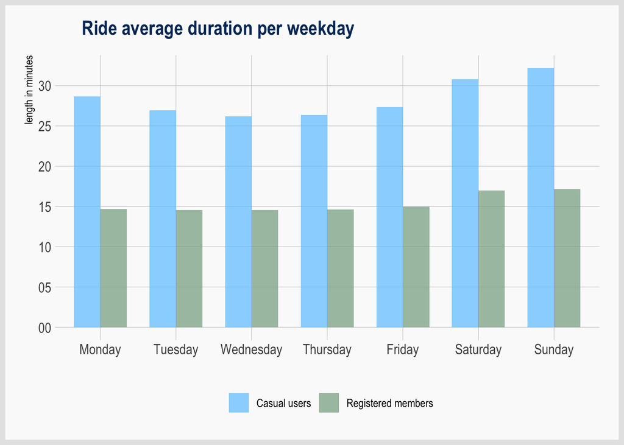

```r
all_trips_v3 %>%
  group_by(user_type, day_of_week) %>%
  summarise(average_duration = mean(ride_length), .groups = 'drop') %>%
  arrange(user_type, day_of_week) %>%
  ggplot(aes(day_of_week, average_duration, fill = user_type)) +
  geom_col(width=.7, position = "dodge") +
  theme_ipsum() +
  xlab("") + ylab("") +
  ggtitle("Ride average duration per weekday") +
  theme(plot.title = element_text(face = "bold", color = "#003366", size = 16, hjust = 0.1, vjust = 2),
        plot.margin = margin(0.7, 0.7, 0.7, 0.7, "cm"),
        plot.background = element_rect(fill = "grey98", colour = "grey90", size = 4),
        axis.text = element_text(size = rel(0.8)),
        legend.title = element_blank(),
        legend.position = "bottom") +
  scale_fill_manual(labels = c("Casual users", "Registered members"), values = alpha(c("#69c6ff", "#81A88D"), 0.7)) +
  scale_y_time(name = "length in minutes", labels = function(l) strftime(l, '%M'), breaks = c(0, 300, 600, 900, 1200, 1500, 1800), minor_breaks = seq(0, 1, 1))
```

- Key findings:
  - Casual users:
    - Lower average on Wednesdays and Thursdays; growing from Fridays with peak on Sundays, then falling on Mondays.
  - Registered members:
    - Business days average duration is almost uniform; small increase on weekends.

## 8.4 Distance traveled

- Average distance by `user_type` and `rideable_type`.

### 8.4.1 Average distance boxplot

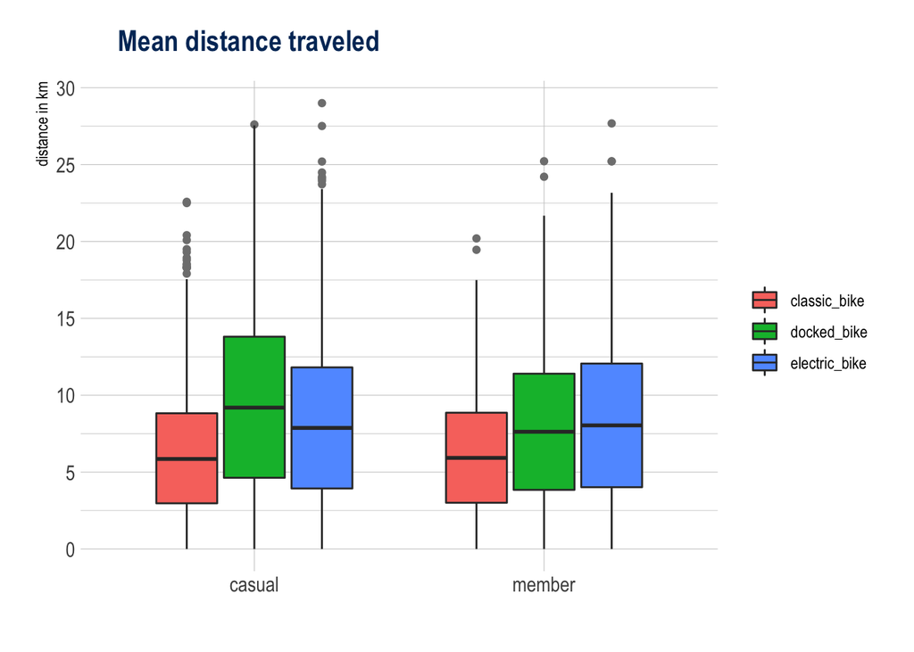

```r
all_trips_v3 %>%
  group_by(rideable_type, user_type, ride_distance) %>%
  summarise(average_distance = mean(ride_distance), .groups = 'drop') %>%
  arrange(user_type, rideable_type) %>%
  ggplot(aes(x = user_type, y = average_distance, fill = rideable_type)) +
  geom_boxplot(width=.7, outlier.color = "grey50") +
  theme_ipsum() +
  xlab("") + ylab("") +
  ggtitle("Mean distance traveled") +
  theme(plot.title = element_text(face = "bold", color = "#003366", size = 16, hjust = 0.1, vjust = 2),
        plot.margin = margin(0.7, 0.7, 0.7, 0.7, "cm"),
        axis.text = element_text(size = rel(0.8)),
        legend.title = element_blank()) +
  scale_y_continuous(name = "distance in km", breaks = c(0, 5, 10, 15, 20, 25, 30))
```

### 8.4.2 Boxplot summary data

```r
bp <- all_trips_v3 %>%
  group_by(rideable_type, user_type, ride_distance) %>%
  summarise(average_distance = mean(ride_distance), .groups = 'drop') %>%
  arrange(user_type, rideable_type) %>%
  ggplot(aes(x = user_type, y = average_distance, fill = rideable_type)) +
  geom_boxplot()
layer_data(bp)
```

```
##      fill ymin  lower middle   upper  ymax
## 1 #F8766D    0 2.9725  5.855  8.8275 17.55
## 2 #00BA38    0 4.6325  9.195 13.8075 27.55
## 3 #619CFF    0 3.9375  7.875 11.8125 23.41
## 4 #F8766D    0 3.0075  5.925  8.8625 17.49
## 5 #00BA38    0 3.8475  7.625 11.4025 21.68
## 6 #619CFF    0 4.0200  8.040 12.0600 23.17
##                                                                                                  outliers
## 1 17.91, 18.29, 18.30, 18.31, 18.32, 18.47, 18.54, 18.79, 18.94, 19.31, 19.50, 20.09, 20.41, 22.50, 22.58
## 2                                                                                                   27.61
## 3                                                  23.72, 23.95, 24.09, 24.20, 24.49, 25.20, 27.51, 29.00
## 4                                                                                            19.46, 20.20
## 5                                                                                            24.21, 25.22
## 6                                                                                     25.21, 25.22, 27.68
##   notchupper notchlower    x flipped_aes PANEL group ymin_final ymax_final
## 1   6.127321   5.582679 0.75       FALSE     1     1          0      22.58
## 2   9.534244   8.855756 1.00       FALSE     1     2          0      27.61
## 3   8.188422   7.561578 1.25       FALSE     1     3          0      29.00
## 4   6.195684   5.654316 1.75       FALSE     1     4          0      20.20
## 5   7.931984   7.318016 2.00       FALSE     1     5          0      25.22
## 6   8.356691   7.723309 2.25       FALSE     1     6          0      27.68
##     xmin   xmax weight colour size alpha shape linetype
## 1 0.6375 0.8625      1 grey20  0.5    NA    19    solid
## 2 0.8875 1.1125      1 grey20  0.5    NA    19    solid
## 3 1.1375 1.3625      1 grey20  0.5    NA    19    solid
## 4 1.6375 1.8625      1 grey20  0.5    NA    19    solid
## 5 1.8875 2.1125      1 grey20  0.5    NA    19    solid
## 6 2.1375 2.3625      1 grey20  0.5    NA    19    solid
```

- Key findings:
  - Classic and electric bikes: both rider types with very similar results.
  - Docked bikes:
    - Casual users: perform longer trips;
    - Registered members: perform shorter trips.
- Ride distance x Weekday

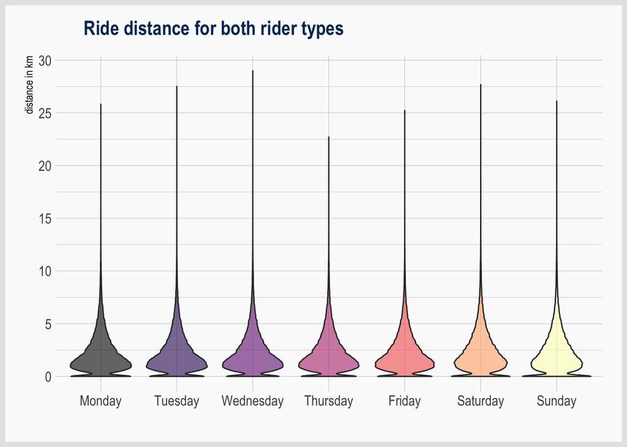

```r
all_trips_v3 %>%
  ggplot(aes(x = day_of_week, y = ride_distance, fill = day_of_week)) +
  geom_violin() +
  scale_fill_viridis(discrete = TRUE, alpha=0.6, option="A") +
  theme_ipsum() +
  xlab("") + ylab("") +
  ggtitle("Ride distance for both rider types") +
  theme(plot.title = element_text(face = "bold", color = "#003366", size = 16, hjust = 0.1, vjust = 2),
        plot.margin = margin(0.7, 0.7, 0.7, 0.7, "cm"),
        plot.background = element_rect(fill = "grey98", colour = "grey90", size = 4),
        axis.text = element_text(size = rel(0.8)),
        legend.position="none") +
  scale_y_continuous(name = "distance in km", breaks = c(0, 5, 10, 15, 20, 25, 30))
```

- Ride distance x Weekday **with filter**

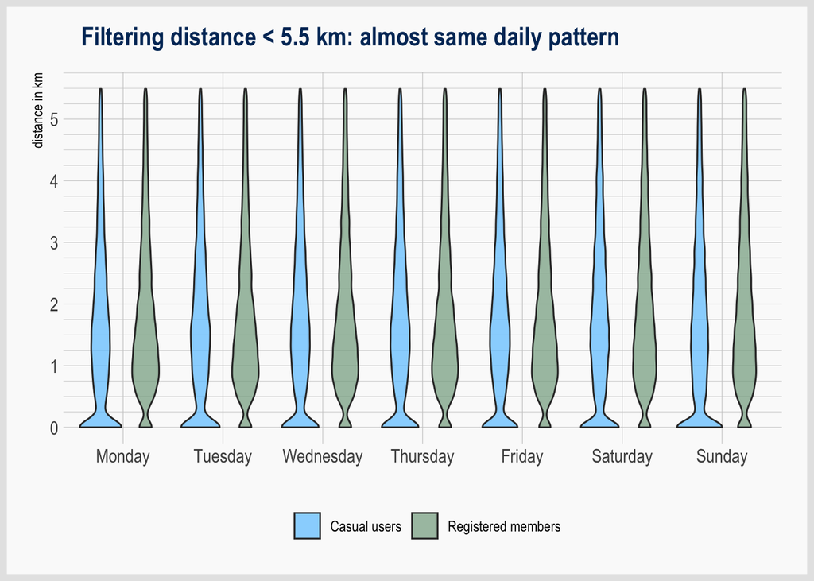

```r
all_trips_v3 %>%
  filter(ride_distance < 5.5) %>%
  ggplot(aes(day_of_week, ride_distance, fill = user_type)) +
  geom_violin() +
  theme_ipsum() +
  xlab("") + ylab("") +
  ggtitle("Filtering distance < 5.5 km: almost same daily pattern") +
  theme(plot.title = element_text(face = "bold", color = "#003366", size = 16, hjust = 0.1, vjust = 2),
        plot.margin = margin(0.7, 0.7, 0.7, 0.7, "cm"),
        plot.background = element_rect(fill = "grey98", colour = "grey90", size = 4),
        axis.text = element_text(size = rel(0.8)),
        legend.position = "bottom",
        legend.title = element_blank()) +
  scale_fill_manual(
    labels = c("Casual users", "Registered members"),
    values = alpha(c("#69c6ff", "#81A88D"), 0.7)) +
  scale_y_continuous(name = "distance in km", breaks = c(0, 1, 2, 3, 4, 5), minor_breaks = seq(0, 10, 0.25))
```

- Key findings:
  - Above the 2 km distance mark the pattern is very similar for both rider types.
  - Casual users:
    - Many rides up to 250 meters long and most of them around 750 meters.
  - Registered members:
    - Few rides up to 250 meters long but a huge increase after that value.